# finalCodeandTechnicalAnalysis

### Confusion Matrix plots at different accuracy

```r
ConfusionMatrixInfo <- function( data, predict, actual, cutoff )
{
    predict <- data[[predict]]
    actual  <- relevel( as.factor( data[[actual]] ), "1" )

    result <- data.table( actual = actual, predict = predict )
    result[ , type := ifelse( predict >= cutoff & actual == 1, "TP",
                      ifelse( predict >= cutoff & actual == 0, "FP",
                      ifelse( predict <  cutoff & actual == 1, "FN", "TN" ) ) ) %>% as.factor() ]

    # jittering : can spread the points along the x axis
    plot <- ggplot( result, aes( actual, predict, color = type ) ) +
            geom_violin( fill = "white", color = NA ) +
            geom_jitter( shape = 1 ) +
            geom_hline( yintercept = cutoff, color = "blue", alpha = 0.6 ) +
            scale_y_continuous( limits = c( 0, 1 ) ) +
            scale_color_discrete( breaks = c( "TP", "FN", "FP", "TN" ) ) + # ordering of the legend
            guides( col = guide_legend( nrow = 2 ) ) + # adjust the legend to have two rows
            ggtitle( sprintf( "ConfusionMatrix Cutoff : %.2f", cutoff ) )

    return( list( data = result, plot = plot ))
}
```

####Left : before SMOTE, Right : after SMOTE

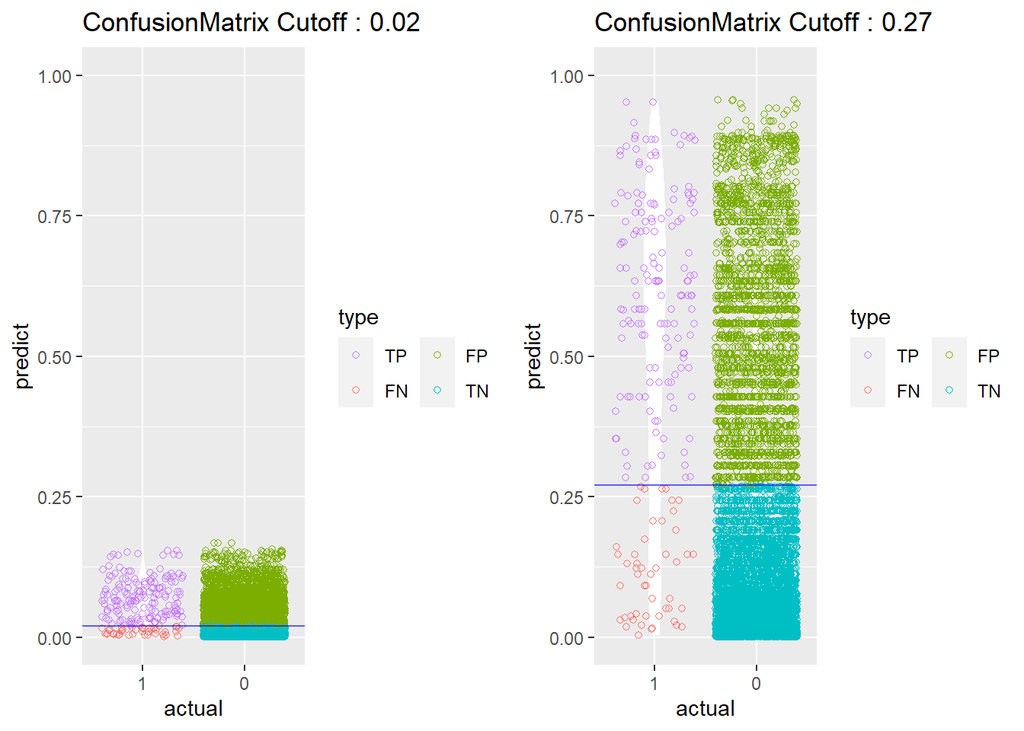

```r
# visualize .6 cutoff (lowest point of the previous plot)
# cm_info <- ConfusionMatrixInfo( data = test, predict = "prediction",
#                                 actual = "stroke", cutoff = .08 )
# #ggthemr("flat")
# cm_info$plot
par(mfrow = c(1, 2))
list1 <- ConfusionMatrixInfo( data = test, predict = "prediction", actual = "stroke", cutoff = .02 )
list2 <- ConfusionMatrixInfo( data = testAfterSMOTE, predict = "prediction", actual = "stroke", cutoff = .27 )
ggp1 <- list1$plot
ggp2 <- list2$plot
grid.arrange(ggp1, ggp2, ncol = 2)
```

The cutoff value that we selected are because of the below curves for(sensitivity, precision, f1 score). The plot of confusion matric is shown first to give a clear idea of the distribution.

### Accuracy versus Cutoff

####Left : before SMOTE, Right : after SMOTE

```r
# ------------------------------------------------------------------------------------------
# [AccuracyCutoffInfo] :
# Obtain the accuracy on the trainining and testing dataset.
# for cutoff value ranging from .4 to .8 ( with a .05 increase )
# @train   : your data.table or data.frame type training data ( assumes you have the predicted score in it ).
# @test    : your data.table or data.frame type testing data
# @predict : prediction's column name (assumes the same for training and testing set)
# @actual  : actual results' column name
# returns  : 1. data : a data.table with three columns.
#                      each row indicates the cutoff value and the accuracy for the
#                      train and test set respectively.
#            2. plot : plot that visualizes the data.table
AccuracyCutoffInfo <- function( train, test, predict, actual )
{
    cutoff <- seq( .01, .9, by = .05 )
    accuracy <- lapply( cutoff, function(c)
    {
      data_train <- as.factor( as.numeric( train[[predict]] > c ) )
        cm_train <- confusionMatrix(data_train, as.factor(train[[actual]]),positive="1" )
        data_test <- as.factor( as.numeric( test[[predict]] > c ) )
        cm_test  <- confusionMatrix( data_test, as.factor(test[[actual]]),positive="1" )

        dt <- data.table( cutoff = c,
                          train  = cm_train$overall[["Accuracy"]],
                        test   = cm_test$overall[["Accuracy"]] )
        return(dt)
    }) %>% rbindlist()

    # visualize the accuracy of the train and test set for different cutoff value
    # accuracy in percentage.
    accuracy_long <- gather( accuracy, "data", "accuracy", -1 )
    plot <- ggplot( accuracy_long, aes( cutoff, accuracy, group = data, color = data ) ) +
            geom_line( size = 1 ) + geom_point( size = 3 ) +
            scale_y_continuous( label = percent ) +
            ggtitle( "Train/Test Accuracy vs Cutoff" )
    return( list( data = accuracy, plot = plot ) )
}
```

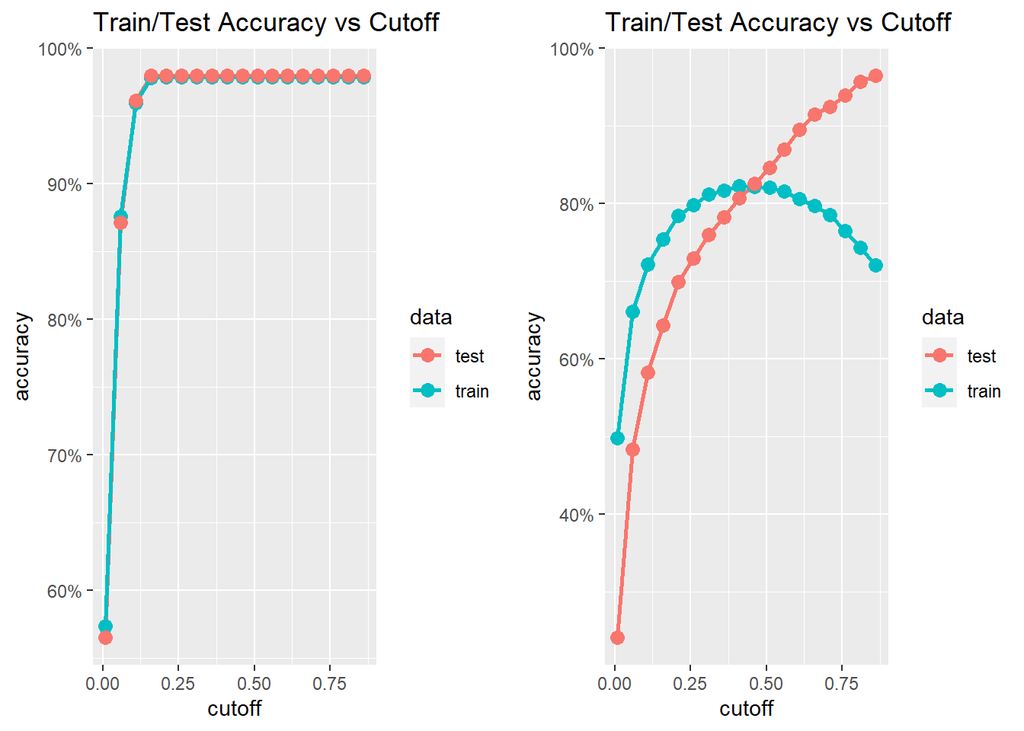

```r
par(mfrow = c(1, 2))
list1 <- AccuracyCutoffInfo( train = beforeSMOTE, test = test, predict = "prediction", actual = "stroke" )
list2<- AccuracyCutoffInfo( train = afterSMOTE, test = testAfterSMOTE, predict = "prediction", actual = "stroke" )
ggp1 <- list1$plot
ggp2 <- list2$plot
grid.arrange(ggp1, ggp2, ncol = 2)
```

Now if observe the accuracy curve,

- For before SMOTE, accuracy keeps on increasing an reaches a plateau after 0.1  
  reason : if the model classifies all data points as 0, it would achieve a accuracy of 9793/(9793+202) = 97.9%
- For After SMOTE, since for training data we have a significant number of 1 , the probability values are distributed well between 0 to 1. and thus with the increase in cutoff. so the drop in accuracy of training dataset with the increase in cutoff is explained by the fact that a significant number of 1’s are now wrongly predicted.
- Since testing data is similar, even with the well spreaded values of 0 and 1, even though the density of 1 is more above cutoff, the significantly high number of 0’s are overpowering that thing and thus the accuracy keeps on increasing here as well for test dataset.

####So how should we evaluate our model then?

The above results confirms that in cases with rare disease or imbalance, it is not a good idea to look at accuracy values. So instead of that we will focus more on the parameters that are more medically sound.  
What do you think can be more important for medical studies?  
We would be more interested in a model which is more sensitive toward people getting stroke.

The parameters that would consider these things are :

- Sensitivity : Percentage of people with stroke who were correctly identified as getting stroke

So that more number of people who are going to get stroke can be made caution and protected

- Precision : the probability that a patient diagnosed as stroke by the classifier got stroke.  
  So for whatever people the model is predicting as will get stroke, how many of them are actually getting it. This will make the situation less chaotic among population and make the positive stroke value as more serious.  
  Hence, we would be more interested in **Sensitivity and Precision** value. Let’s observe them for our model.

### Sensitivity versus cutoff

```r
SensitivityCutoffInfo <- function( train, test, predict, actual )
{
    cutoff <- seq( .01, .9, by = .05 )
    accuracy <- lapply( cutoff, function(c)
    {
      data_train <- as.factor( as.numeric( train[[predict]] > c ) )
        cm_train <- confusionMatrix(data_train, as.factor(train[[actual]]),positive="1" )
        data_test <- as.factor( as.numeric( test[[predict]] > c ) )
        cm_test  <- confusionMatrix( data_test, as.factor(test[[actual]]),positive="1" )

        dt <- data.table( cutoff = c,
                          train  = cm_train$byClass[["Sensitivity"]],
                        test   = cm_test$byClass[["Sensitivity"]] )
        return(dt)
    }) %>% rbindlist()
    accuracy_long <- gather( accuracy, "data", "accuracy", -1 )

    plot <- ggplot( accuracy_long, aes( cutoff, accuracy, group = data, color = data ) ) +
            geom_line( size = 1 ) + geom_point( size = 3 ) +
            scale_y_continuous( label = percent ) +
            ggtitle( "Train/Test Sensivity vs Cutoff" )+
        ylab("Sensitivity")

    return( list( data = accuracy, plot = plot ) )
}
```

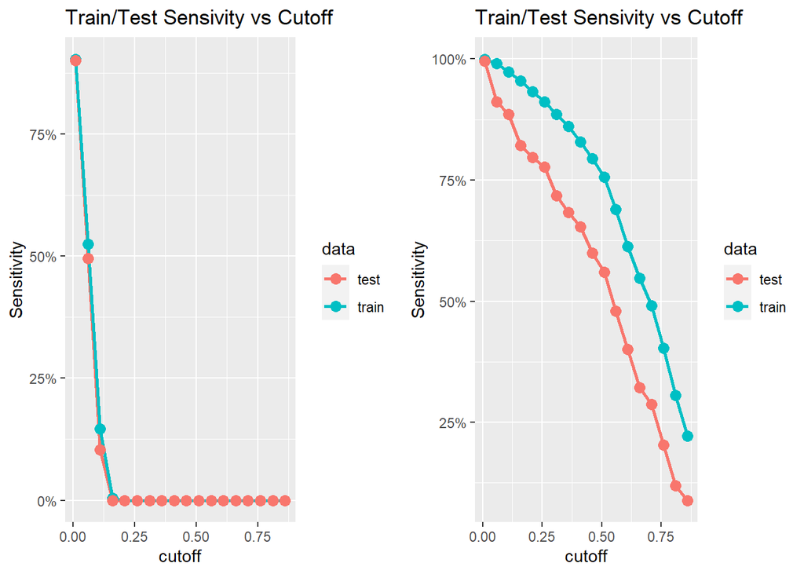

```r
par(mfrow = c(1, 2))
list1 <- SensitivityCutoffInfo( train = beforeSMOTE, test = test, predict = "prediction", actual = "stroke" )
list2<- SensitivityCutoffInfo( train = afterSMOTE, test = testAfterSMOTE, predict = "prediction", actual = "stroke" )
ggp1 <- list1$plot
ggp2 <- list2$plot
grid.arrange(ggp1, ggp2, ncol = 2)
```

So why is the sensitivity value decreasing so rapidly?  
Left curve - before SMOTE  
since all the predicted probabilities are between 0&0.25. after 0 and 0.25, all the datapoints which had stroke = 1, are predicted as 0, the sensitivity is dropping so rapidly.  
Right Curve - after SMOTE  
train - since the number of 0 & 1 are more balanced, and the probability values are spreaded well between 0 - 1, the drop in sensitivity value is smooth.  
test - the datapoints are now well spreaded between 0 & 1, hence the curve is now smooth

### Precision versus cutoff

```r
PrecisionCutoffInfo <- function( train, test, predict, actual )
{
    cutoff <- seq( .01, .9, by = .05 )
    accuracy <- lapply( cutoff, function(c)
    {
      data_train <- as.factor( as.numeric( train[[predict]] > c ) )
        cm_train <- confusionMatrix(data_train, as.factor(train[[actual]]),positive="1" )
        data_test <- as.factor( as.numeric( test[[predict]] > c ) )
        cm_test  <- confusionMatrix( data_test, as.factor(test[[actual]]),positive="1" )

        dt <- data.table( cutoff = c,
                          train  = cm_train$byClass[["Precision"]],
                        test   = cm_test$byClass[["Precision"]] )
        return(dt)
    }) %>% rbindlist()
    accuracy_long <- gather( accuracy, "data", "accuracy", -1 )

    plot <- ggplot( accuracy_long, aes( cutoff, accuracy, group = data, color = data ) ) +
            geom_line( size = 1 ) + geom_point( size = 3 ) +
            scale_y_continuous( label = percent ) +
            ggtitle( "Train/Test Precision vs Cutoff" )+
        ylab("Precision")

    return( list( data = accuracy, plot = plot ) )
}
```

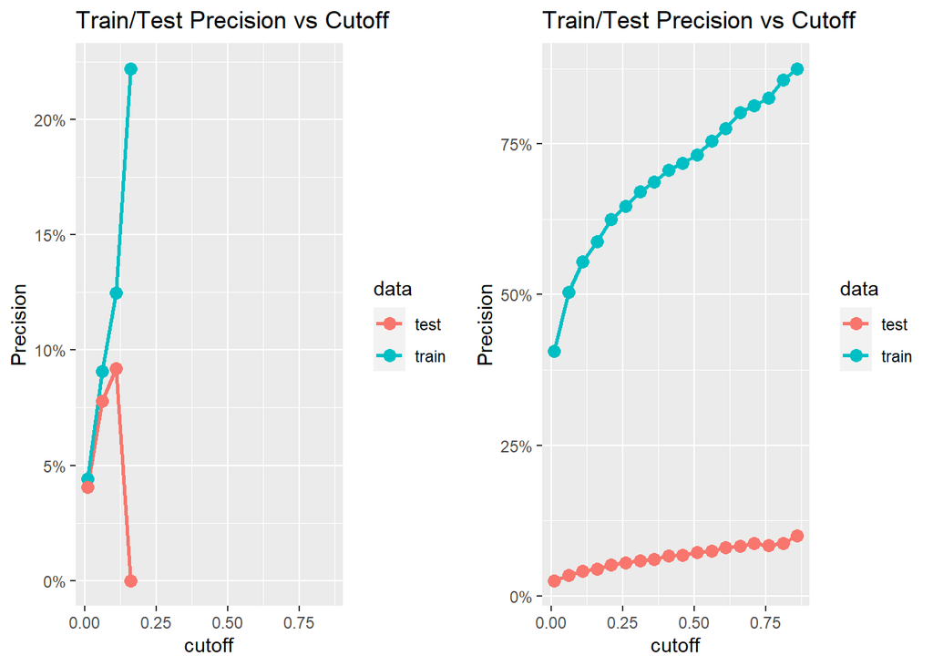

```r
par(mfrow = c(1, 2))
list1 <- PrecisionCutoffInfo( train = beforeSMOTE, test = test, predict = "prediction", actual = "stroke" )
list2<- PrecisionCutoffInfo( train = afterSMOTE, test = testAfterSMOTE, predict = "prediction", actual = "stroke" )
ggp1 <- list1$plot
ggp2 <- list2$plot
grid.arrange(ggp1, ggp2, ncol = 2)
```

### F1 Score versus cutoff

```r
FOneCutoffInfo <- function( train, test, predict, actual )
{
    cutoff <- seq( .01, .9, by = .05 )
    accuracy <- lapply( cutoff, function(c)
    {
      data_train <- as.factor( as.numeric( train[[predict]] > c ) )
        cm_train <- confusionMatrix(data_train, as.factor(train[[actual]]),positive="1" )
        data_test <- as.factor( as.numeric( test[[predict]] > c ) )
        cm_test  <- confusionMatrix( data_test, as.factor(test[[actual]]),positive="1" )

        dt <- data.table( cutoff = c,
                          train  = cm_train$byClass[["F1"]],
                        test   = cm_test$byClass[["F1"]] )
        return(dt)
    }) %>% rbindlist()
    accuracy_long <- gather( accuracy, "data", "accuracy", -1 )

    plot <- ggplot( accuracy_long, aes( cutoff, accuracy, group = data, color = data ) ) +
            geom_line( size = 1 ) + geom_point( size = 3 ) +
            scale_y_continuous( label = percent ) +
            ggtitle( "Train/Test F1 vs Cutoff" )+
        ylab("F1 Score")

    return( list( data = accuracy, plot = plot ) )
}
```

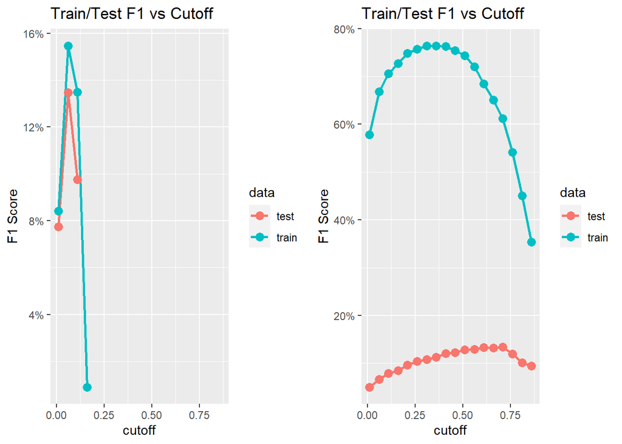

```r
par(mfrow = c(1, 2))
list1 <- FOneCutoffInfo( train = beforeSMOTE, test = test, predict = "prediction", actual = "stroke" )
list2<- FOneCutoffInfo( train = afterSMOTE, test = testAfterSMOTE, predict = "prediction", actual = "stroke" )
ggp1 <- list1$plot
ggp2 <- list2$plot
grid.arrange(ggp1, ggp2, ncol = 2)
```

The higher the precision recall score, the higher would be the F1 score, hence a high F1 score means a better model.

Before SMOTE

```r
c_b <- 0.02

beforeSMOTEpred <- as.factor( as.numeric( test[["prediction"]] > c_b ) )
cm_test_b <- confusionMatrix(beforeSMOTEpred, as.factor(test$stroke),positive="1" )
cm_test_b
```

```
## Confusion Matrix and Statistics
##
##           Reference
## Prediction    0    1
##          0 6819   42
##          1 2974  160
##
##                Accuracy : 0.6982
##                  95% CI : (0.6891, 0.7072)
##     No Information Rate : 0.9798
##     P-Value [Acc > NIR] : 1
##
##                   Kappa : 0.0602
##
##  Mcnemar's Test P-Value : <0.0000000000000002
##
##             Sensitivity : 0.79208
##             Specificity : 0.69631
##          Pos Pred Value : 0.05105
##          Neg Pred Value : 0.99388
##              Prevalence : 0.02021
##          Detection Rate : 0.01601
##    Detection Prevalence : 0.31356
##       Balanced Accuracy : 0.74420
##
##        'Positive' Class : 1
##
```

- F1 score : 0.0959233
- Sensitivity : 0.7920792
- Precision : 0.051053

After SMOTE

```r
c_a <- 0.27
afterSMOTEpred <- as.factor( as.numeric( testAfterSMOTE[["prediction"]] > c_a ) )
cm_test_a <- confusionMatrix(afterSMOTEpred, as.factor(testAfterSMOTE$stroke),positive="1" )
cm_test_a
```

```
## Confusion Matrix and Statistics
##
##           Reference
## Prediction    0    1
##          0 7244   49
##          1 2549  153
##
##                Accuracy : 0.7401
##                  95% CI : (0.7314, 0.7486)
##     No Information Rate : 0.9798
##     P-Value [Acc > NIR] : 1
##
##                   Kappa : 0.0704
##
##  Mcnemar's Test P-Value : <0.0000000000000002
##
##             Sensitivity : 0.75743
##             Specificity : 0.73971
##          Pos Pred Value : 0.05662
##          Neg Pred Value : 0.99328
##              Prevalence : 0.02021
##          Detection Rate : 0.01531
##    Detection Prevalence : 0.27034
##       Balanced Accuracy : 0.74857
##
##        'Positive' Class : 1
##
```

- F1 score : 0.1053719
- Sensitivity : 0.7574257
- Precision : 0.0566247

### Deciding the cut off level

```r
# setting the cut-off probablity
# function to print confusion matrices for diffrent cut-off levels of probability
#to get confusion matrix checking the max probability from the graph
#for before SMOTE
max_prob_b <- max(test$prediction)
min_prob_b <- min(test$prediction)
jump_b <-  0.01


# making sequence of cut-off probabilities
cutoff_b <- seq( min_prob_b, max_prob_b, by = jump_b )
CmFn <- function(cutoff,model) {
       # predicting the test set results
         modelPred <- predict(model, test, type = "response")
         C1 <- ifelse(modelPred > cutoff, 1, 0)
         C2 <- test$stroke
         predY   <- as.factor(C1)
         actualY <- as.factor(C2)
        # use the confusionMatrix
        cm1 <-confusionMatrix(table(predY,actualY),positive="1")
        #print(cutoff)
        #print(cm1$table)
        # extracting accuracy
        Accuracy <- cm1$overall[1]
        #print(Accuracy)
        # extracting sensitivity
          Sensitivity <- cm1$byClass[1]
        # extracting specificity
          Specificity <- cm1$byClass[2]
      # extracting value of Precision
          Precision <- cm1$byClass[5]
      #f1 score
          f1_score <- cm1$byClass[7]
        # combined table
          tab <- cbind(cutoff,Accuracy,Sensitivity,Specificity,Precision,f1_score)
        return(tab)}

# loop using "lapply"
#tab2    <- lapply(cutoff1, CmFn)
tab_b    <- lapply(cutoff_b, CmFn,logitModel_b)
#tab2 <- CmFn(logitModel1_a,test,cutoff1)
#tab_b
```

```r
max_prob_a <- max(testAfterSMOTE$prediction)
min_prob_a <- min(testAfterSMOTE$prediction)
jump_a <-  0.1

cutoff_a <- seq( min_prob_a, max_prob_a, by = jump_a )
tab_a <-lapply(cutoff_a, CmFn,logitModel_a)
```

### ROC - AUC Curve

####for ubalanced dataset

```r
# loading the package

library(pROC)
#loadPkg("pROC") # receiver operating characteristic curve, gives the diagnostic ability of a binary classifier system as its discrimination threshold is varied. The curve is on sensitivity/recall/true-positive-rate vs false_alarm/false-positive-rate/fall-out.
prob=predict(logitModel_b,test, type = "response")
#Admit$prob=prob
h <- roc(stroke~prob, data=test,levels = c(1, 0))
auc(h) # area-under-curve prefer 0.8 or higher.
```

```
## Area under the curve: 0.8147
```

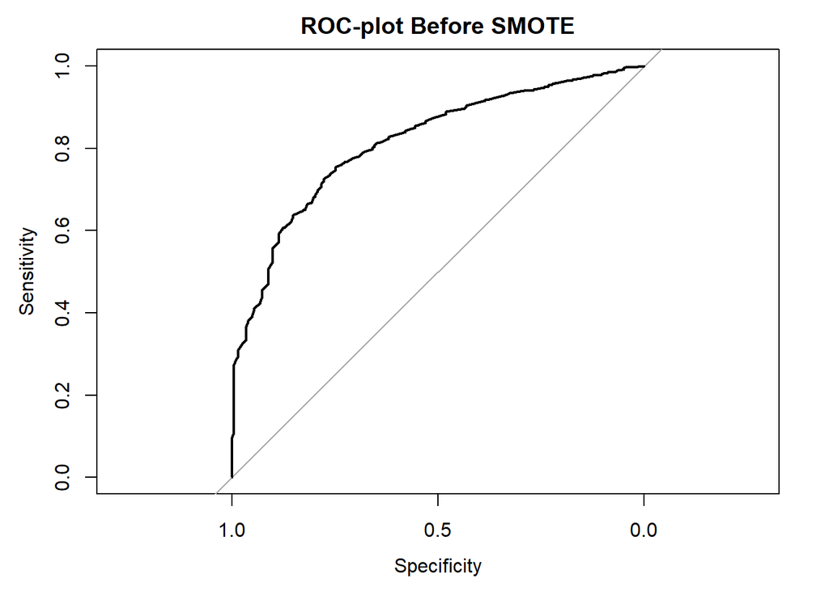

```r
plot(h,main="ROC-plot Before SMOTE")
```

Area under curve is 0.81

####After SMOTEbalanced dataset

```r
prob=predict(logitModel_a,testAfterSMOTE, type = "response")
#Admit$prob=prob
h_logistic <- roc(stroke~prob, data=testAfterSMOTE)
```

```r
auc(h_logistic) # area-under-curve prefer 0.8 or higher.
```

```
## Area under the curve: 0.8096
```

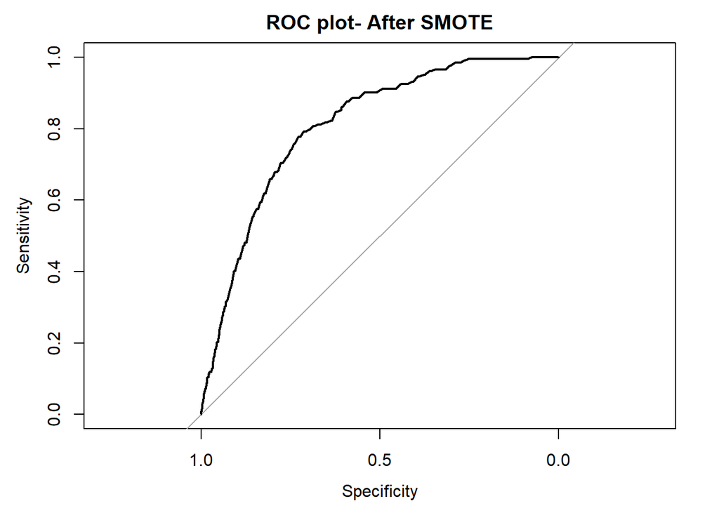

```r
plot(h_logistic,main="ROC plot- After SMOTE")
```

Area under curve is 0.809

Now why is there no significant difference in the ROC curve value ?  
This is because the testing dataset is same for both and the number of values for 1 are significantly small.

### PR Curve

Always a good idea to plot a precision recall curve when we are more interested in one class out of the two. Our aim is to make the curve as close to (1, 1) as possible- meaning a good precision and recall

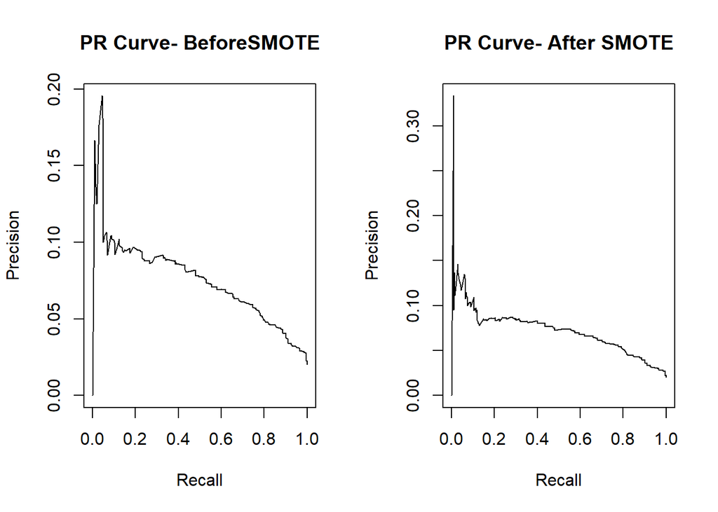

```r
# Predict
pred = predict(logitModel_b,test, type = "response")
# Store precision and recall scores at different cutoffs
par(mfrow = c(1, 2))
library(ROCR)
predobj <- prediction(pred, test$stroke)
perf <- performance(predobj,"prec", "rec")
ggp1<- plot(perf,main="PR Curve- BeforeSMOTE")

#Predict
pred = predict(logitModel_a,testAfterSMOTE, type = "response")
predobj <- prediction(pred, testAfterSMOTE$stroke)
perf <- performance(predobj,"prec", "rec")
ggp2<-plot(perf,main="PR Curve- After SMOTE")
```

```r
grid.arrange(ggp1, ggp2, ncol = 2)
```

###Solution

Our results will improve if we generate more entries in test dataset as well corresponding to stroke =1.

```r
testDataAfterSmote <- SMOTE(stroke ~ ., test, perc.over = 2000, perc.under = 100)
test_0 <- subset(testDataAfterSmote,testDataAfterSmote$stroke==0)
test_1 <- subset(testDataAfterSmote,testDataAfterSmote$stroke==1)
print(nrow(test_1))
```

```
## [1] 4242
```

```r
print(nrow(test_0))
```

```
## [1] 4040
```

```r
testDataAfterSmote$glucoseGroup=cut(testDataAfterSmote$avg_glucose_level, c(0, 114, 140, Inf), c("Normal", "Prediabetes", "Diabetes"), include.lowest=TRUE)
```

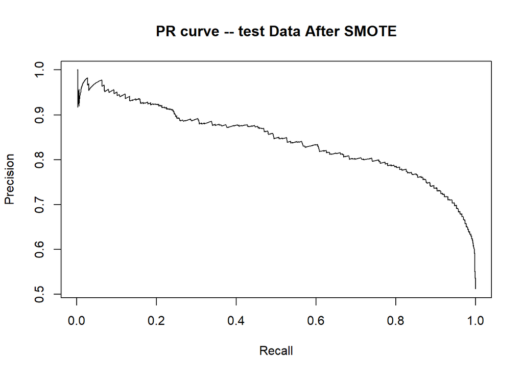

```r
# Predict
pred = predict(logitModel_a,testDataAfterSmote, type = "response")
# Store precision and recall scores at different cutoffs
library(ROCR)
predobj <- prediction(pred, testDataAfterSmote$stroke)
perf <- performance(predobj,"prec", "rec")
ggp2<-plot(perf,main="PR curve -- test Data After SMOTE")
```

```r
#prob=predict(logitModel_a,testAfterSMOTE, type = "response")
#Admit$prob=prob
h <- roc(stroke~pred, data=testDataAfterSmote)
```

```r
auc(h) # area-under-curve prefer 0.8 or higher.
```

```
## Area under the curve: 0.862
```

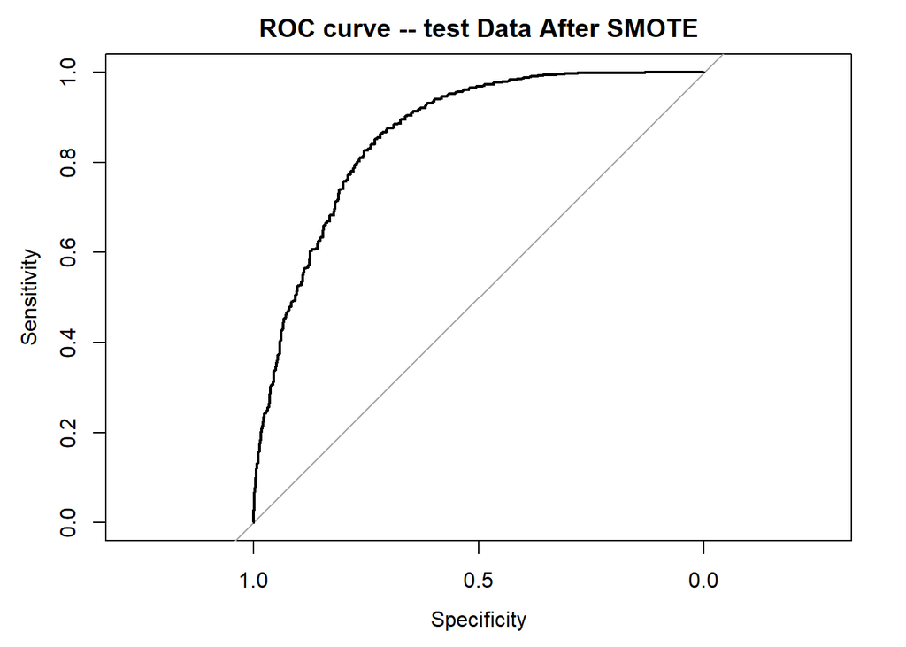

```r
plot(h,main="ROC curve -- test Data After SMOTE")
```

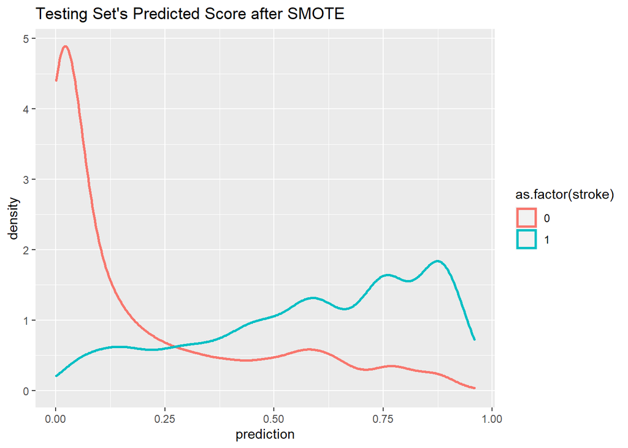

```r
testDataAfterSmote$prediction = predict(logitModel_a,testDataAfterSmote, type = "response")
ggplot( testDataAfterSmote, aes( prediction, color = as.factor(stroke) ) ) +
geom_density( size = 1 ) +
ggtitle( "Testing Set's Predicted Score after SMOTE" )
```

Conclusion :

- we cannot upsample more datapoints in medical dataset so we will need to ask for more entries with the disease(stroke=1)
- or more significant terms for the model, which have a huge impact on the disease itself.

###Plotting all the three models

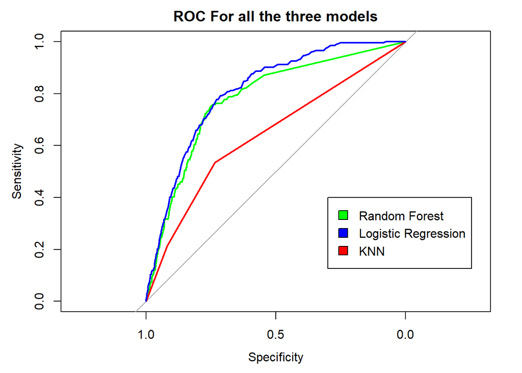

```r
plot(ROC_rf, col = "green", main = "ROC For all the three models")
plot(h_KNN, add=TRUE, col="red")
plot(h_logistic, add=TRUE, col='blue')
legend(0.3,0.4,legend=c("Random Forest", "Logistic Regression","KNN" ),
       fill = c("green","blue", "red"))
```

So, for our dataset, logistic regression gives the best results.